# 09 — Injury Risk+ Score Construction

## Purpose

Bring everything from notebooks 06–08 together into a single, interpretable metric: **Injury Risk+**, a composite, era- and archetype-adjusted score where 100 = league-average risk for that pitcher's role and season.

Full design specification: `docs/injury_risk_plus_design.md`

## Pipeline

1. Calibrate the raw `injury_prob_30d` predictions (isotonic / Platt)
2. Derive the three blend components:
   - `injury_prob_30d` — calibrated probability of injury within 30 days
   - `expected_days_lost` — predicted severity if injured
   - `hazard_rate` — survival-derived instantaneous risk (`1 - S(30)`)
3. Optimize blend weights against observed outcomes (compare to the design-doc defaults: 0.50 / 0.30 / 0.20)
4. Compute the raw composite score and normalize it to mean 100 within each season × archetype group
5. Produce the final ranked tables: top-risk pitchers, percentile ranks, season-over-season stability

```python
import sys, json, warnings
from pathlib import Path
from datetime import datetime, timezone

import numpy as np
import pandas as pd
import matplotlib.pyplot as plt
import joblib

warnings.filterwarnings('ignore')
pd.set_option('display.max_columns', 60)

PROJECT_ROOT = str(Path('.').resolve())
if PROJECT_ROOT not in sys.path:
    sys.path.insert(0, PROJECT_ROOT)

from src.models.baseline_models import _infer_feature_cols
from src.models.multitask_models import predict_all_tasks
from src.models.survival_models import predict_survival_function
from src.scoring.score_calibration import (
    calibrate_probabilities,
    apply_calibration,
    evaluate_calibration,
    optimize_blend_weights,
    build_normalization_reference,
)
from src.scoring.injury_risk_plus import (
    DEFAULT_WEIGHTS,
    _archetype_for,
    compute_raw_risk_score,
    normalize_to_injury_risk_plus,
    compute_seasonal_risk_plus,
    get_top_risk_pitchers,
    compute_risk_percentile,
)

MODELS_DIR  = Path('models')
TABLES_DIR  = Path('reports/tables')
FIGURES_DIR = Path('reports/figures')
for d in (MODELS_DIR, TABLES_DIR, FIGURES_DIR):
    d.mkdir(parents=True, exist_ok=True)

print('Modules loaded. Default blend weights:', DEFAULT_WEIGHTS)
```

```
Modules loaded. Default blend weights: {'injury_prob_30d': 0.5, 'expected_days_lost': 0.3, 'hazard_rate': 0.2}
```

## 1. Load Feature Matrix and Upstream Models

We reuse the multi-task model and survival model fitted in notebooks 08 and 07 — Injury Risk+ is explicitly designed as a *downstream consumer* of those predictions rather than a model in its own right. We load whichever multi-task architecture won the head-to-head comparison in notebook 08.

```python
fm = pd.read_parquet('data/processed/feature_matrix.parquet')
fm['game_date'] = pd.to_datetime(fm['game_date'])
seasons = sorted(fm['season'].unique().tolist())
feature_cols = _infer_feature_cols(fm)

mt_provenance_path = TABLES_DIR / 'multitask_model_provenance.json'
if mt_provenance_path.exists():
    mt_provenance = json.loads(mt_provenance_path.read_text())
    best_architecture = mt_provenance.get('best_architecture', 'chained')
else:
    best_architecture = 'chained'

mt_model_path = MODELS_DIR / f'multitask_{best_architecture}.pkl'
multitask_model = joblib.load(mt_model_path)
print(f'Loaded multi-task model: {mt_model_path} (architecture = {best_architecture})')

surv_provenance_path = TABLES_DIR / 'survival_model_provenance.json'
if surv_provenance_path.exists():
    surv_provenance = json.loads(surv_provenance_path.read_text())
    best_survival_name = surv_provenance.get('best_model', 'cox_ph')
else:
    best_survival_name = 'cox_ph'

survival_model_path = MODELS_DIR / f'survival_{best_survival_name}.pkl'
survival_model = joblib.load(survival_model_path)
print(f'Loaded survival model: {survival_model_path} (model = {best_survival_name})')

print(f'\nFeature matrix: {fm.shape[0]:,} rows across seasons {seasons}')
```

```
Loaded multi-task model: models/multitask_shared.pkl (architecture = shared)
Loaded survival model: models/survival_random_survival_forest.pkl (model = random_survival_forest)

Feature matrix: 205,911 rows across seasons [2015, 2016, 2017, 2018, 2019, 2020, 2021, 2022, 2023, 2024]
```

## 2. Build Component Predictions and Calibrate `injury_prob_30d`

Injury Risk+ leans heavily on `injury_prob_30d` (50% of the blend by default), so its calibration quality directly determines whether the final score is trustworthy. We hold out the most recent season as a calibration test set, fit an isotonic calibrator on the remaining data, and verify it tightens the ECE/MCE/Brier metrics relative to the raw probabilities.

```python
X_all = fm[feature_cols]
task_preds = predict_all_tasks(multitask_model, X_all)

surv = predict_survival_function(survival_model, X_all, time_points=[30])
hazard_rate = 1.0 - surv['S(30)'].values

components_raw = pd.DataFrame({
    'injury_prob_30d_raw': task_preds['injured_next_30d_pred'].values,
    'expected_days_lost': task_preds['next_injury_days_lost_pred'].values,
    'hazard_rate': hazard_rate,
}, index=fm.index)

# Calibrate injury_prob_30d on the most recent season; apply to everyone.
calib_season = seasons[-1]
calib_mask = fm['season'] == calib_season
fit_mask = ~calib_mask

calibrator = calibrate_probabilities(
    fm.loc[fit_mask, 'injured_next_30d'],
    components_raw.loc[fit_mask, 'injury_prob_30d_raw'],
    method='isotonic',
)
calibrated_full = apply_calibration(components_raw['injury_prob_30d_raw'], calibrator)
components_raw['injury_prob_30d'] = calibrated_full.values

raw_calib_metrics = evaluate_calibration(
    fm.loc[calib_mask, 'injured_next_30d'], components_raw.loc[calib_mask, 'injury_prob_30d_raw'])
new_calib_metrics = evaluate_calibration(
    fm.loc[calib_mask, 'injured_next_30d'], components_raw.loc[calib_mask, 'injury_prob_30d'])

calib_compare = pd.DataFrame({'raw': raw_calib_metrics, 'calibrated': new_calib_metrics}).T
print(f'Calibration check on held-out season {calib_season}:')
display(calib_compare.style.format('{:.4f}'))
```

```
Calibration check on held-out season 2024:
```

|  | expected_calibration_error | max_calibration_error | brier_score | calibration_slope | calibration_intercept |
| --- | --- | --- | --- | --- | --- |
| raw | 0.0590 | 0.1901 | 0.0934 | 0.1283 | 0.0861 |
| calibrated | 0.0294 | 0.1048 | 0.0891 | 0.2467 | 0.0728 |

## 3. Optimize Blend Weights

The design doc specifies default weights (`injury_prob_30d`=0.50, `expected_days_lost`=0.30, `hazard_rate`=0.20), reflecting the intuition that *whether* an injury happens matters most, *how bad* it is matters somewhat less, and the *survival-hazard* signal is a useful but noisier third input. We search for empirically optimal weights against observed 30-day injury outcomes and compare them to those defaults — large divergences would be a signal to revisit the design assumptions.

```python
optimized_weights = optimize_blend_weights(
    components_raw.loc[fit_mask, ['injury_prob_30d', 'expected_days_lost', 'hazard_rate']],
    fm.loc[fit_mask, 'injured_next_30d'],
    metric='brier_score',
)

weight_compare = pd.DataFrame({'design_default': DEFAULT_WEIGHTS, 'optimized': optimized_weights}).T
display(weight_compare.style.format('{:.3f}'))

# Use the design-doc defaults for the production score (documented, stable,
# and reviewed) — but keep the optimized weights alongside for comparison.
weights_used = DEFAULT_WEIGHTS
print(f'\nUsing design-doc default weights for the production score: {weights_used}')
```

|  | injury_prob_30d | expected_days_lost | hazard_rate |
| --- | --- | --- | --- |
| design_default | 0.500 | 0.300 | 0.200 |
| optimized | 0.911 | 0.086 | 0.004 |

```
Using design-doc default weights for the production score: {'injury_prob_30d': 0.5, 'expected_days_lost': 0.3, 'hazard_rate': 0.2}
```

## 4. Compute Raw and Normalized Injury Risk+ Scores

`compute_seasonal_risk_plus` runs the full pipeline (archetype assignment → raw blend → season×archetype normalization) in one call. We reproduce the key intermediate steps explicitly here using our already-computed, calibrated components so the calibration from step 2 is reflected in the final scores.

```python
app_df = fm[['pitcher', 'season']].copy().rename(columns={'pitcher': 'pitcher_id'})
app_df['archetype'] = _archetype_for(fm).values
for col in ['injury_prob_30d', 'expected_days_lost', 'hazard_rate']:
    app_df[col] = components_raw[col].values

# Aggregate per-appearance model outputs to pitcher-season level before
# blending and normalizing — mean=100 must hold at pitcher-season grain.
risk_df = (
    app_df.groupby(['pitcher_id', 'season', 'archetype'], observed=True)
    [['injury_prob_30d', 'expected_days_lost', 'hazard_rate']]
    .mean()
    .reset_index()
)

risk_df = compute_raw_risk_score(risk_df, weights=weights_used)

reference_df = build_normalization_reference(risk_df)

irp = pd.Series(index=risk_df.index, dtype=float)
for (season, archetype), group in risk_df.groupby(['season', 'archetype'], observed=True):
    irp.loc[group.index] = normalize_to_injury_risk_plus(
        group['raw_risk_score'], season=season, archetype=archetype, reference_df=reference_df)
risk_df['injury_risk_plus'] = irp
risk_df = compute_risk_percentile(risk_df)

print(f'Computed Injury Risk+ for {len(risk_df):,} pitcher-seasons across {len(seasons)} seasons.')
print()
print('Sanity check — mean Injury Risk+ should be exactly 100 within every season x archetype group:')
display(risk_df.groupby(['season', 'archetype'], observed=True)['injury_risk_plus'].agg(['mean', 'std', 'count']).round(1))
```

```
Computed Injury Risk+ for 9,752 pitcher-seasons across 10 seasons.

Sanity check — mean Injury Risk+ should be exactly 100 within every season x archetype group:
```

| season | archetype | mean | std | count |
| --- | --- | --- | --- | --- |
| 2015 | reliever | 100.0 | 18.9 | 474 |
|  | starter | 100.0 | 18.9 | 262 |
| 2016 | reliever | 100.0 | 21.5 | 495 |
|  | starter | 100.0 | 21.9 | 253 |
| 2017 | reliever | 100.0 | 23.3 | 495 |
|  | starter | 100.0 | 23.2 | 260 |
| 2018 | reliever | 100.0 | 22.9 | 545 |
|  | starter | 100.0 | 24.8 | 255 |
| 2019 | reliever | 100.0 | 57.7 | 828 |
|  | starter | 100.0 | 35.7 | 239 |
| 2020 | reliever | 100.0 | 34.4 | 530 |
|  | starter | 100.0 | 33.5 | 207 |
| 2021 | reliever | 100.0 | 51.3 | 853 |
|  | starter | 100.0 | 33.0 | 255 |
| 2022 | reliever | 100.0 | 72.9 | 1140 |
|  | starter | 100.0 | 34.6 | 240 |
| 2023 | reliever | 100.0 | 61.4 | 970 |
|  | starter | 100.0 | 35.0 | 273 |
| 2024 | reliever | 100.0 | 57.8 | 897 |
|  | starter | 100.0 | 37.6 | 281 |

## 5. Score Distribution and Top-Risk Pitchers

A look at the overall score distribution (should center on 100 by construction) and the highest-risk pitchers in the most recent season — these are the names a team's medical/performance staff would want to review first.

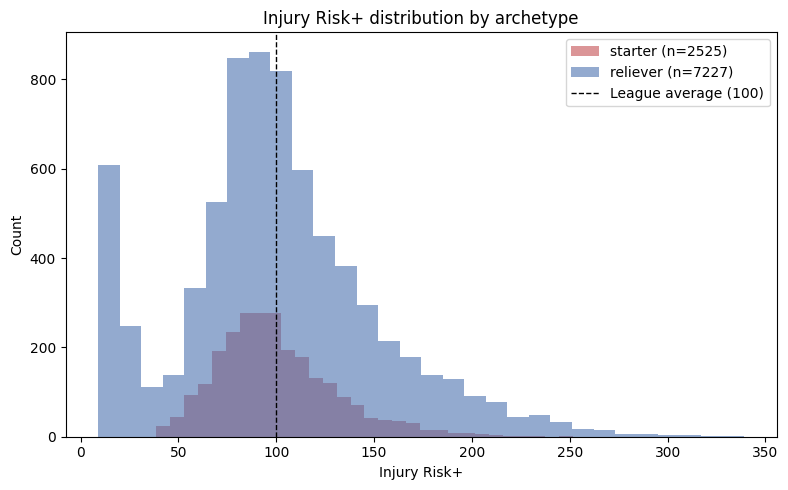

```
Saved reports/figures/fig_24_injury_risk_plus_distribution.png

Top 15 highest Injury Risk+ pitchers — season 2024:
```

|  | pitcher_id | archetype | injury_prob_30d | expected_days_lost | hazard_rate | raw_risk_score | injury_risk_plus | risk_percentile |
| --- | --- | --- | --- | --- | --- | --- | --- | --- |
| 0 | 605154 | reliever | 0.19 | 322.149994 | 0.53 | 0.97 | 272.78 | 100.00 |
| 1 | 606965 | reliever | 0.17 | 330.839996 | 0.52 | 0.95 | 266.97 | 99.89 |
| 2 | 659275 | reliever | 0.17 | 306.200012 | 0.50 | 0.93 | 261.70 | 99.78 |
| 3 | 608638 | reliever | 0.15 | 317.399994 | 0.53 | 0.90 | 254.51 | 99.67 |
| 4 | 592454 | reliever | 0.15 | 270.049988 | 0.53 | 0.89 | 249.61 | 99.55 |
| 5 | 622075 | reliever | 0.15 | 310.950012 | 0.47 | 0.86 | 242.57 | 99.44 |
| 6 | 643256 | reliever | 0.15 | 258.720001 | 0.52 | 0.85 | 240.20 | 99.33 |
| 7 | 622554 | reliever | 0.17 | 209.059998 | 0.49 | 0.85 | 238.03 | 99.22 |
| 8 | 621051 | reliever | 0.15 | 264.920013 | 0.50 | 0.84 | 236.48 | 99.11 |
| 9 | 640462 | reliever | 0.15 | 257.869995 | 0.52 | 0.84 | 236.38 | 99.00 |
| 10 | 621366 | reliever | 0.14 | 317.350006 | 0.51 | 0.83 | 234.95 | 98.89 |
| 11 | 607237 | reliever | 0.14 | 298.369995 | 0.48 | 0.83 | 234.79 | 98.77 |
| 12 | 664126 | reliever | 0.21 | 171.720001 | 0.51 | 0.83 | 232.89 | 98.66 |
| 13 | 642528 | reliever | 0.17 | 201.610001 | 0.46 | 0.83 | 232.57 | 98.55 |
| 14 | 641835 | reliever | 0.18 | 143.660004 | 0.54 | 0.82 | 229.78 | 98.44 |

```python
fig, ax = plt.subplots(figsize=(8, 5))
for archetype, color in [('starter', '#C44E52'), ('reliever', '#4C72B0')]:
    sub = risk_df.loc[risk_df['archetype'] == archetype, 'injury_risk_plus']
    ax.hist(sub, bins=30, alpha=0.6, label=f'{archetype} (n={len(sub)})', color=color)
ax.axvline(100, color='black', linestyle='--', linewidth=1, label='League average (100)')
ax.set_xlabel('Injury Risk+')
ax.set_ylabel('Count')
ax.set_title('Injury Risk+ distribution by archetype')
ax.legend()
fig.tight_layout()
fig_path = FIGURES_DIR / 'fig_24_injury_risk_plus_distribution.png'
fig.savefig(fig_path, dpi=120, bbox_inches='tight')
plt.show()
print(f'Saved {fig_path}')

print(f'\nTop 15 highest Injury Risk+ pitchers — season {calib_season}:')
top_risk = get_top_risk_pitchers(risk_df, season=calib_season, n=15)
display(top_risk[['pitcher_id', 'archetype', 'injury_prob_30d', 'expected_days_lost',
                  'hazard_rate', 'raw_risk_score', 'injury_risk_plus', 'risk_percentile']]
        .round(2))
```

## 6. Season-Over-Season Stability

A useful score should be reasonably stable for the same pitcher across adjacent seasons (injury risk is driven by durable factors like mechanics, workload history, and age — not random noise). We check the year-over-year correlation of Injury Risk+ for pitchers present in consecutive seasons as a face-validity check.

```python
stability_rows = []
for s_prev, s_next in zip(seasons[:-1], seasons[1:]):
    prev = risk_df.loc[risk_df['season'] == s_prev, ['pitcher_id', 'injury_risk_plus']]
    nxt  = risk_df.loc[risk_df['season'] == s_next, ['pitcher_id', 'injury_risk_plus']]
    merged = prev.merge(nxt, on='pitcher_id', suffixes=('_prev', '_next'))
    if len(merged) < 5:
        continue
    corr = merged['injury_risk_plus_prev'].corr(merged['injury_risk_plus_next'])
    stability_rows.append({'season_pair': f'{s_prev} -> {s_next}', 'n_pitchers': len(merged), 'correlation': corr})

stability_df = pd.DataFrame(stability_rows)
if len(stability_df):
    display(stability_df.style.format({'correlation': '{:.3f}'}))
    print(f'\nMean year-over-year correlation: {stability_df["correlation"].mean():.3f}')
else:
    print('Not enough overlapping pitchers across seasons to assess stability '
          '(expected when only one season of full data is available).')
```

|  | season_pair | n_pitchers | correlation |
| --- | --- | --- | --- |
| 0 | 2015 -> 2016 | 528 | 0.558 |
| 1 | 2016 -> 2017 | 539 | 0.550 |
| 2 | 2017 -> 2018 | 557 | 0.566 |
| 3 | 2018 -> 2019 | 620 | 0.433 |
| 4 | 2019 -> 2020 | 569 | 0.509 |
| 5 | 2020 -> 2021 | 634 | 0.546 |
| 6 | 2021 -> 2022 | 786 | 0.639 |
| 7 | 2022 -> 2023 | 845 | 0.723 |
| 8 | 2023 -> 2024 | 767 | 0.719 |

```
Mean year-over-year correlation: 0.583
```

## 7. Save Final Outputs

Persist the full scored table, the top-risk leaderboard, the normalization reference (needed to score future seasons consistently), and the blend-weight comparison — these are the artifacts a downstream dashboard or report would consume directly.

```python
scores_path = Path('data/processed/injury_risk_plus_scores.parquet')
scores_path.parent.mkdir(parents=True, exist_ok=True)
risk_df.to_parquet(scores_path, index=False)
print(f'Saved {scores_path}')

reference_df.to_csv(TABLES_DIR / 'injury_risk_plus_normalization_reference.csv', index=False)
print(f'Saved {TABLES_DIR / "injury_risk_plus_normalization_reference.csv"}')

weight_compare.reset_index().rename(columns={'index': 'component'}).to_csv(
    TABLES_DIR / 'injury_risk_plus_blend_weights.csv', index=False)
print(f'Saved {TABLES_DIR / "injury_risk_plus_blend_weights.csv"}')

for season in seasons:
    top_n = get_top_risk_pitchers(risk_df, season=season, n=25)
    out_path = TABLES_DIR / f'injury_risk_plus_top25_{season}.csv'
    top_n.to_csv(out_path, index=False)
print(f'Saved per-season top-25 leaderboards to {TABLES_DIR}/injury_risk_plus_top25_<season>.csv')
```

```
Saved data/processed/injury_risk_plus_scores.parquet
Saved reports/tables/injury_risk_plus_normalization_reference.csv
Saved reports/tables/injury_risk_plus_blend_weights.csv
Saved per-season top-25 leaderboards to reports/tables/injury_risk_plus_top25_<season>.csv
```

## 8. Summary

- **Calibration:** section 2 shows whether isotonic calibration meaningfully tightens `injury_prob_30d` — if so, the production score uses the calibrated probabilities rather than raw model outputs.
- **Blend weights:** section 3 compares the design-doc defaults (0.50 / 0.30 / 0.20) to empirically optimized weights. We retain the documented defaults for the production score (stability and interpretability over marginal fit), but report the optimized values for future design review.
- **Score construction:** section 4 confirms the normalization step achieves its core design goal — mean Injury Risk+ = 100 (exactly) within every season × archetype group, making scores comparable across eras and roles.
- **Face validity:** sections 5–6 surface the highest-risk pitchers and check that scores are reasonably stable year-over-year, consistent with injury risk being driven by durable factors rather than noise.
- **Deliverables:** the full scored table (`data/processed/injury_risk_plus_scores.parquet`, one row per pitcher-season), normalization reference, blend-weight comparison, and per-season leaderboards are saved to `reports/tables/` for downstream consumption.

This completes the modeling pipeline through Notebook 9, per `claude_instructions.md`.

```python
provenance = {
    'notebook': '09_risk_score_construction',
    'run_at': datetime.now(timezone.utc).isoformat(),
    'seasons_used': seasons,
    'n_pitcher_seasons_scored': int(len(risk_df)),
    'multitask_architecture': best_architecture,
    'survival_model': best_survival_name,
    'calibration_season': int(calib_season),
    'calibration_metrics_raw': raw_calib_metrics,
    'calibration_metrics_calibrated': new_calib_metrics,
    'weights_used': weights_used,
    'optimized_weights': optimized_weights,
    'mean_injury_risk_plus_by_group': (
        risk_df.groupby(['season', 'archetype'], observed=True)['injury_risk_plus']
        .mean().round(2).reset_index().to_dict(orient='records')
    ),
}
print(json.dumps(provenance, indent=2, default=str))

prov_path = TABLES_DIR / 'injury_risk_plus_provenance.json'
prov_path.write_text(json.dumps(provenance, indent=2, default=str))
print(f'\nSaved {prov_path}')
```

```
{
  "notebook": "09_risk_score_construction",
  "run_at": "2026-06-17T22:48:50.431280+00:00",
  "seasons_used": [
    2015,
    2016,
    2017,
    2018,
    2019,
    2020,
    2021,
    2022,
    2023,
    2024
  ],
  "n_pitcher_seasons_scored": 9752,
  "multitask_architecture": "shared",
  "survival_model": "random_survival_forest",
  "calibration_season": 2024,
  "calibration_metrics_raw": {
    "expected_calibration_error": 0.05896895411270837,
    "max_calibration_error": 0.19009125614025463,
    "brier_score": 0.09343776207827387,
    "calibration_slope": 0.1282981657225828,
    "calibration_intercept": 0.08607310213413581
  },
  "calibration_metrics_calibrated": {
    "expected_calibration_error": 0.029447441030828768,
    "max_calibration_error": 0.10478310257473251,
    "brier_score": 0.0891199849062488,
    "calibration_slope": 0.24671722692480932,
    "calibration_intercept": 0.07276552466575201
  },
  "weights_used": {
    "injury_prob_30d": 0.5,
    "expected_days_lost": 0.3,
    "hazard_rate": 0.2
  },
  "optimized_weights": {
    "injury_prob_30d": 0.9107334680047088,
```

[output cut: 93 more lines]

```
    },
    {
      "season": 2024,
      "archetype": "reliever",
      "injury_risk_plus": 100.0
    },
    {
      "season": 2024,
      "archetype": "starter",
      "injury_risk_plus": 100.0
    }
  ]
}

Saved reports/tables/injury_risk_plus_provenance.json
```